# Script R

Chimène NOUICER & Venera SINANAJ

17/11/2025

### INTRODUCTION

L’essor des études sur le bien-être subjectif montre que le bonheur d’une nation est une mesure de sa santé plus complète que seulement les indicateurs économiques.

Notre étude se concentre sur les crimes financiers et économiques - spécifiquement la Fraude, la Corruption et le Blanchiment d’argent. Ils concernent l’argent, les flux financiers ou l’enrichissement illégal et impliquent fraude, corruption, ou dissimulation de fonds. Ils relèvent de la criminalité financière dans toutes les normes criminologiques internationales.

Ces délits peuvent éroder la confiance institutionnelle et la perception d’équité, deux piliers fondamentaux de la satisfaction citoyenne. En quantifiant, ce préjudice social indirect, nous cherchons à évaluer le coût humain de l’illégalité financière.

Nous allons alors nous demander si les crimes financiers et économiques impactent la satisfaction globale de la vie pour les citoyens d’un pays.

Notre modèle est le suivant :
$$Satisfaction = \beta_0 + \beta_1 log(Fraude) + \beta_2 log(Fraude)^2 +
\beta_3 log(Blanchiment) + \beta_4 log(Corruption) + \beta_5
log(Blanchiment)*log(Corruption) +\varepsilon$$
Il est composé des variables suivantes :

- `corruption`: Actes illicites tels que défini dans la Convention des Nations Unies contre la corruption et dans d’autres instruments juridiques nationaux et internationaux contre la corruption.
- `fraude`: Obtention d’argent ou d’un autre avantage, ou évitement d’une responsabilité, par la tromperie ou un comportement malhonnête.
- `blanchiment`: Conversion ou transfert de biens en sachant que ces biens proviennent d’une infraction, dans le but de dissimuler ou masquer l’origine illicite de ces biens ou d’aider toute personne impliquée dans la commission de l’infraction initiale à échapper aux conséquences juridiques de ses actes. Cela inclut également la dissimulation ou la falsification de la véritable nature, origine, localisation, disposition, mouvement ou propriété des biens, ou des droits liés à ces biens.
- `satisfaction`: Pourcentage de répondants ayant déclaré être ’très heureux” ou “plutôt heureux” lorsqu’on leur a posé la question : “En prenant tout en compte, diriez-vous que vous être très heureux, plutôt heureux, pas très heureux ou pas du tout heureux ?”. Elle est définie comme une mesure subjective autodéclarée par les individus, reflétant leur évaluation cognitive globale de leur propre vie et de leurs conditions de vie.

# Base de données

Les variables sont issues des bases de données suivantes :

- UNODC (2025), UNODC Research - Data Portal – Corruption and Economic Crime. https://dataunodc.un.org/dp-crime-corruption-offences
- Integrated Values Surveys (2024) – with major processing by Our World in Data. “Share of people who say they are happy – Integrated Values Surveys” [dataset]. Integrated Values Surveys, “Integrated Values Surveys (IVS) Version 4” [original data]. Retrieved November 19, 2025 from https://ourworldindata.org/grapher/share-of-people-who-say-they-are-happy?country=GEO~IND~ZWE~BRA (archived on September 9, 2025)

(Nous avons retiré certains pays des analyses, par manque de données pour toutes les variables).

# On télécharge les données

```r
library(dplyr)
library(ggplot2)
library(stargazer)
library(corrplot)
library(readxl)
library(skimr)

library(lmtest)
library(moments)
library(patchwork)
library(car)
library(texreg)

# On télécharge les données
happiness <- read_excel("C:/Users/vener/Desktop/Econométrie R/Oral R/Base de données.xlsx")
library(ggplot2)

# Visualisation rapide de la base de données
head(happiness)
```

```
## # A tibble: 6 × 5
##   Country                 `Corruption (x2)` Blanchiment d'argent…¹ `Fraude (x1)`
##   <chr>                               <dbl>                  <dbl>         <dbl>
## 1 Albania                             41.7                 16.8          34.3
## 2 Austria                             34.0                  8.33        777.
## 3 Bolivia (Plurinational…              3.57                 0.944         0.0414
## 4 Bosnia and Herzegovina              21.7                  3.56         18.2
## 5 Bulgaria                             7.82                 0.601        33.7
## 6 Chile                                1.84                 0.0102      376.
## # ℹ abbreviated name: ¹`Blanchiment d'argent (x3)`
## # ℹ 1 more variable: `Satisfaction globale (Y)` <chr>
```

# On renomme correctement les variables (chaque colonne de la base de données correspond à une variable)

```r
happiness <- happiness %>% rename(
  Satisfaction = "Satisfaction globale (Y)",
  Fraude = "Fraude (x1)",
  Blanchiment = "Blanchiment d'argent (x3)",
  Corruption = "Corruption (x2)"
)
names(happiness)
```

```
## [1] "Country"      "Corruption"   "Blanchiment"  "Fraude"       "Satisfaction"
```

```r
View(happiness)
```

# On va vérifer que l’unité de chacune de nos variables de notre modèle soit en numérique

```r
happiness$`Fraude` <- as.numeric(gsub(",", ".", happiness$`Fraude`))
happiness$`Corruption` <- as.numeric(gsub(",", ".", happiness$`Corruption`))
happiness$`Blanchiment` <- as.numeric(gsub(",", ".", happiness$`Blanchiment`))
happiness$`Satisfaction`<-as.numeric(gsub(",", ".", happiness$`Satisfaction`))
```

# On visualise grossièrement nos variables

```r
str(happiness)
```

```
## tibble [38 × 5] (S3: tbl_df/tbl/data.frame)
##  $ Country     : chr [1:38] "Albania" "Austria" "Bolivia (Plurinational State of)" "Bosnia and Herzegovina" ...
##  $ Corruption  : num [1:38] 41.73 34.03 3.57 21.66 7.82 ...
##  $ Blanchiment : num [1:38] 16.799 8.329 0.944 3.557 0.601 ...
##  $ Fraude      : num [1:38] 34.2692 776.9609 0.0414 18.2227 33.6807 ...
##  $ Satisfaction: num [1:38] 73.9 89.1 73 87 60.2 ...
```

# On sélectionne nos variables de notre modèle pour faire de la statistique descriptive

```r
xxx <- happiness %>%
  select(Fraude, Blanchiment, Corruption, Satisfaction)

stargazer(as.data.frame(xxx),
          type = "text",
          title = "Table: Descriptive statistics of some variables",
          covariate.labels = c("Fraude", "Blanchiment", "Corruption",
                               "Satisfaction"),
          digits = 2)
```

```
##
## Table: Descriptive statistics of some variables
## ==============================================
## Statistic    N   Mean  St. Dev.  Min    Max
## ----------------------------------------------
## Fraude       38 336.21  455.36  0.04  2,371.72
## Blanchiment  38 11.72   28.10   0.01   142.63
## Corruption   38 22.13   32.50   0.08   185.84
## Satisfaction 38 84.76    7.46   60.17  95.11
## ----------------------------------------------
```

Nous avons 38 observations. Les variables liées aux crimes financiers présentent une forte dispersion (écart type élevé par rapport à la moyenne, il y a donc beaucoup de différences entre les observations : certaines sont très petites, d’autres très grandes) et des valeurs extrêmes. La satisfaction est concentrée autour de 85 %, avec peu de variation entre pays.

# On cherche à voir si nos variables sont corrélées en construisant le tableau de corrélation

```r
corr.matrix <- cor(xxx)
corr.matrix
```

```
##                 Fraude Blanchiment Corruption Satisfaction
## Fraude       1.0000000   0.7690957  0.6849517    0.3926907
## Blanchiment  0.7690957   1.0000000  0.7675485    0.2720772
## Corruption   0.6849517   0.7675485  1.0000000    0.2149114
## Satisfaction 0.3926907   0.2720772  0.2149114    1.0000000
```

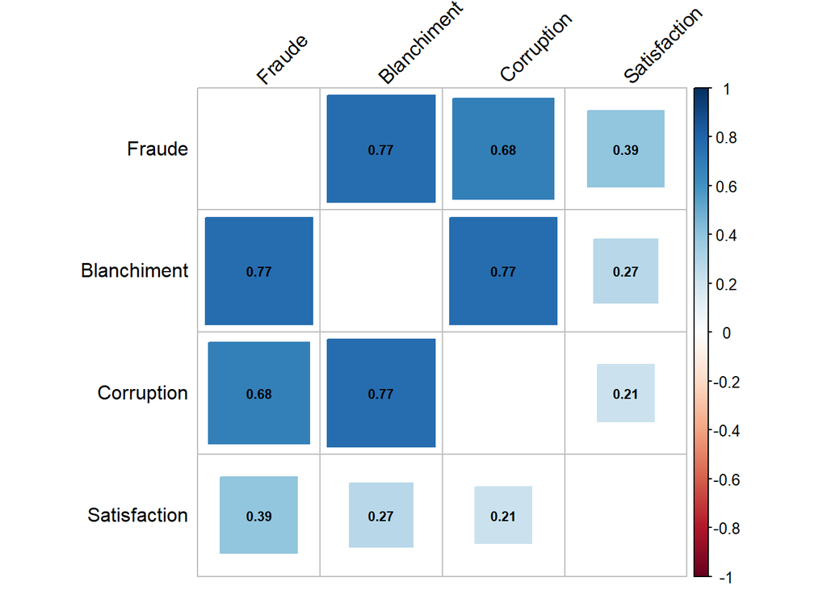

```r
colnames(corr.matrix) <- c("Fraude", "Blanchiment", "Corruption",
                           "Satisfaction")
rownames(corr.matrix) <- colnames(corr.matrix)

corrplot(corr.matrix, method = "square", diag = FALSE,
         addCoef.col = "black", number.cex = 0.7,
         tl.col = "black", tl.srt = 45)
```

Il y a une corrélation positive très forte entre la variable Fraude et la variable Blanchiment (0.77). (Ce qui est logique puisque lorsqu’un pays est victime de fraude alors il subit forcément beaucoup de blanchiment.)

Blanchiment ↔︎ Corruption = 0.77 : forte corrélation positive. Même logique : blanchiment et corruption évoluent ensemble.

Fraude ↔︎ Corruption = 0.68 : corrélation élevée mais un peu moins que les deux précédentes.

Satisfaction ↔︎ Fraude = 0.39 ; Satisfaction ↔︎ Blanchiment = 0.27 ; Satisfaction ↔︎ Corruption = 0.21 : toutes corrélations positives faibles à modérées. Ici, la direction positive signifie que, les pays avec plus de crimes financiers ont tendance à avoir une satisfaction plus élevée, ce qui est contre‑intuitif et mérite vérification.

# On évalue la valeur du skewness (cela sert principalement à comprendre la forme de la distribution de vos variables)

```r
eval_symetrie <- happiness %>% select(Fraude, Blanchiment, Corruption, Satisfaction)
sapply(eval_symetrie, skewness, na.rm = TRUE)
```

```
##       Fraude  Blanchiment   Corruption Satisfaction
##     2.630550     3.627338     3.581258    -1.132001
```

L’analyse de l’asymétrie (skewness) révèle que les variables Fraude (2.63), Blanchiment (3.63) et Corruption (3.58) présentent une très forte asymétrie positive, indiquant la présence de valeurs extrêmes élevées.

La variable Satisfaction (-1.13) signifie qu’il y a une asymétrie négative nette, la majorité des valeurs sont hautes mais quelques valeurs sont très basses qui tirent la distribution vers la gauche.

Il est donc recommandé d’envisager une transformation logarithmique Fraude, Blanchiment, et Corruption, afin d’améliorer la symétrie des distributions et la qualité des estimations économétriques.

# Régression à une variable (Corruption et satisfaction globale de la vie)

$$Satisfaction = \beta_0 + \beta_1 Corruption + \varepsilon$$

```r
reg1 <- lm(Satisfaction ~ Corruption, data = happiness)
summary(reg1)
```

```
##
## Call:
## lm(formula = Satisfaction ~ Corruption, data = happiness)
##
## Residuals:
##     Min      1Q  Median      3Q     Max
## -23.880  -3.548   1.970   4.652  11.441
##
## Coefficients:
##             Estimate Std. Error t value Pr(>|t|)
## (Intercept) 83.66524    1.45558   57.48   <2e-16 ***
## Corruption   0.04932    0.03735    1.32    0.195
## ---
## Signif. codes:  0 '***' 0.001 '**' 0.01 '*' 0.05 '.' 0.1 ' ' 1
##
## Residual standard error: 7.385 on 36 degrees of freedom
## Multiple R-squared:  0.04619,    Adjusted R-squared:  0.01969
## F-statistic: 1.743 on 1 and 36 DF,  p-value: 0.1951
```

Le modèle simple montre un coefficient positif mais non significatif de la corruption sur la satisfaction et un R² très faible. Avec ces données, on ne peut pas conclure qu’il existe un effet linéaire fiable ; il faut ajouter des contrôles, vérifier les outliers et tester des spécifications plus robustes.

# Graphique de la régression (corruption et satisfaction globale de la vie)

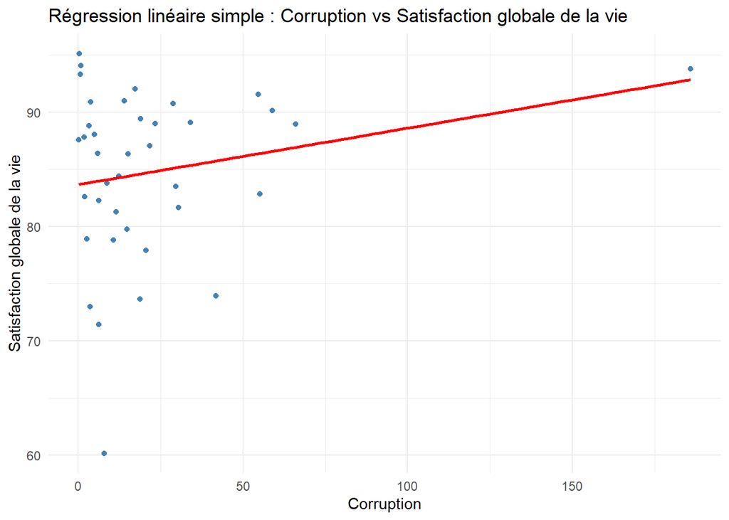

```r
ggplot(happiness, aes(x = Corruption, y = Satisfaction)) +
  geom_point(color = "steelblue") +
  geom_smooth(method = "lm", se = FALSE, color = "red") +
  labs(title = "Régression linéaire simple : Corruption vs Satisfaction globale de la vie",
       x = "Corruption",
       y = "Satisfaction globale de la vie") +
  theme_minimal()
```

Ce modèle linéaire n’est globalement pas significatif. Il n’y a aucune relation linéaire détectable entre Corruption et Satisfaction dans cette forme. Même si la pente est positive, la dispersion suggère que la corrélation est faible et que la droite n’explique pas bien la variation de la satisfaction.

# Régression à une variable (fraude et satisfaction globale de la vie)

$$Satisfaction = \beta_0 + \beta_1 Fraude + \varepsilon$$

```r
reg2 <- lm(Satisfaction ~ Fraude, data = happiness)
summary(reg2)
```

```
##
## Call:
## lm(formula = Satisfaction ~ Fraude, data = happiness)
##
## Residuals:
##      Min       1Q   Median       3Q      Max
## -22.6395  -3.7314   0.4231   4.8067  11.5968
##
## Coefficients:
##              Estimate Std. Error t value Pr(>|t|)
## (Intercept) 82.594295   1.408947  58.621   <2e-16 ***
## Fraude       0.006432   0.002511   2.562   0.0147 *
## ---
## Signif. codes:  0 '***' 0.001 '**' 0.01 '*' 0.05 '.' 0.1 ' ' 1
##
## Residual standard error: 6.954 on 36 degrees of freedom
## Multiple R-squared:  0.1542, Adjusted R-squared:  0.1307
## F-statistic: 6.564 on 1 and 36 DF,  p-value: 0.01474
```

Effet marginal : une augmentation d’une unité de la variable Fraude est associée, en moyenne, à une augmentation de 0.00643 point de la satisfaction.

Mise en perspective : l’effet est numériquement très petit à l’unité. Par exemple, une hausse de 100 unités de Fraude correspond à ≈ 0.64 point de satisfaction; une augmentation d’une écart‑type (≈455) correspond à ≈ 2.9 points de satisfaction. Même si le coefficient est significatif, son ampleur est modeste.

#Graphique de la régression

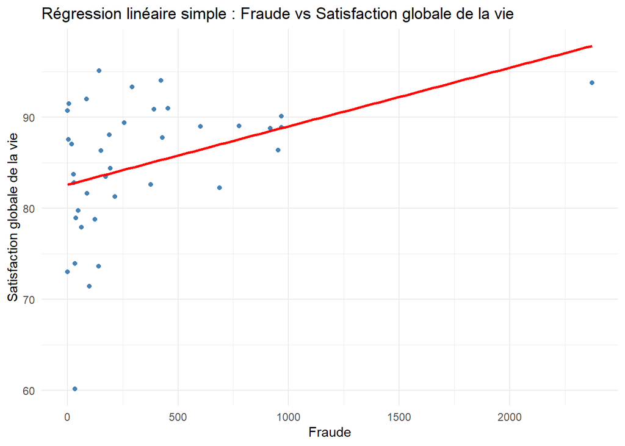

```r
ggplot(happiness, aes(x = Fraude, y = Satisfaction)) +
  geom_point(color = "steelblue") +
  geom_smooth(method = "lm", se = FALSE, color = "red") +
  labs(title = "Régression linéaire simple : Fraude vs Satisfaction globale de la vie",
       x = "Fraude",
       y = "Satisfaction globale de la vie") +
  theme_minimal()
```

#Régression à une variable (blanchiment vs satisfaction globale de la vie)
$$Satisfaction = \beta_0 + \beta_1 Blanchiment + \varepsilon$$

```r
reg3 <- lm(Satisfaction ~ Blanchiment, data = happiness)
summary(reg3)
```

```
##
## Call:
## lm(formula = Satisfaction ~ Blanchiment, data = happiness)
##
## Residuals:
##      Min       1Q   Median       3Q      Max
## -23.7820  -2.8697   0.4535   4.9120  10.4341
##
## Coefficients:
##             Estimate Std. Error t value Pr(>|t|)
## (Intercept) 83.91007    1.28156  65.475   <2e-16 ***
## Blanchiment  0.07223    0.04257   1.696   0.0984 .
## ---
## Signif. codes:  0 '***' 0.001 '**' 0.01 '*' 0.05 '.' 0.1 ' ' 1
##
## Residual standard error: 7.276 on 36 degrees of freedom
## Multiple R-squared:  0.07403,    Adjusted R-squared:  0.0483
## F-statistic: 2.878 on 1 and 36 DF,  p-value: 0.09843
```

Le modèle montre qu’une unité supplémentaire de blanchiment est associée à une hausse moyenne de 0,072 point de satisfaction, mais cet effet reste faible et non significatif. Avec un R² de 7 %, la variable n’explique qu’une petite part de la variation, et la dispersion des résidus suggère que d’autres facteurs clés sont absents du modèle.

#Graphique de la régression

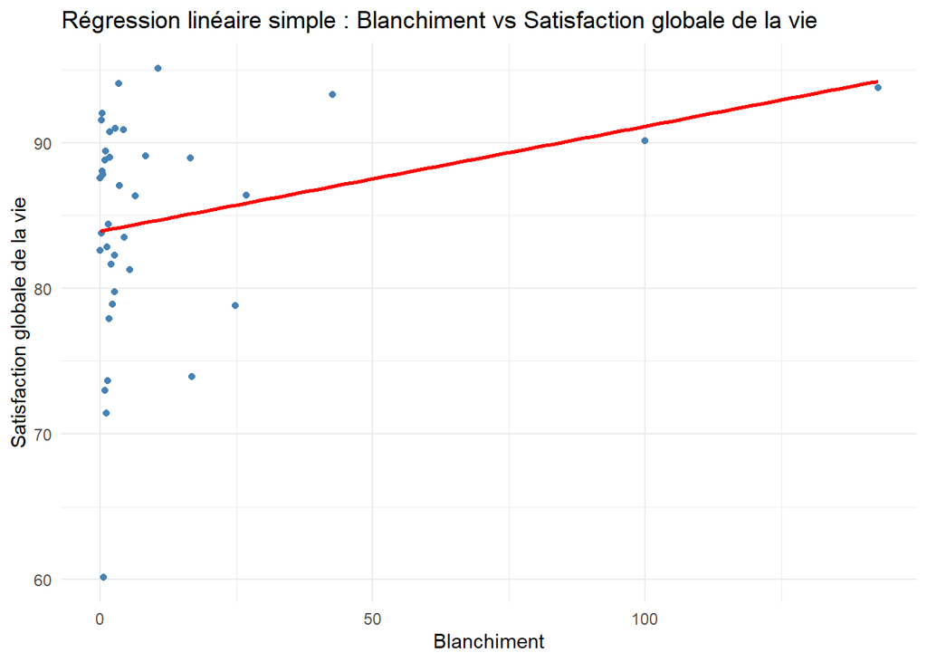

```r
ggplot(happiness, aes(x = Blanchiment, y = Satisfaction)) +
  geom_point(color = "steelblue") +
  geom_smooth(method = "lm", se = FALSE, color = "red") +
  labs(title = "Régression linéaire simple : Blanchiment vs Satisfaction globale de la vie",
       x = "Blanchiment",
       y = "Satisfaction globale de la vie") +
  theme_minimal()
```

Aucune relation statistiquement significative entre Blanchiment et Satisfaction dans ce modèle linéaire.

# Représentation de toutes les régressions simples

```r
screenreg(list(reg1,reg2,reg3), custom.model.names = c("reg corruption","reg fraude", "reg blanchiment"))
```

```
##
## ========================================================
##              reg corruption  reg fraude  reg blanchiment
## --------------------------------------------------------
## (Intercept)  83.67 ***       82.59 ***   83.91 ***
##              (1.46)          (1.41)      (1.28)
## Corruption    0.05
##              (0.04)
## Fraude                        0.01 *
##                              (0.00)
## Blanchiment                               0.07
##                                          (0.04)
## --------------------------------------------------------
## R^2           0.05            0.15        0.07
## Adj. R^2      0.02            0.13        0.05
## Num. obs.    38              38          38
## ========================================================
## *** p < 0.001; ** p < 0.01; * p < 0.05
```

En conclusion, les trois modèles linéaires montrent que Corruption et Blanchiment n’ont pas d’effet statistiquement significatif sur la satisfaction globale de la vie.

En revanche il peut y avoir une légère correlation entre Fraude Satisfaction.

# Régression multiple

$$Satisfaction = \beta_0 + \beta_1 Fraude + \beta_2 Blanchiment + \beta_3
Corruption +\varepsilon$$

```r
reg4 <- lm(Satisfaction ~ Fraude + Blanchiment + Corruption, data = happiness )
summary(reg4)
```

```
##
## Call:
## lm(formula = Satisfaction ~ Fraude + Blanchiment + Corruption,
##     data = happiness)
##
## Residuals:
##      Min       1Q   Median       3Q      Max
## -22.6137  -3.2868   0.7501   4.8172  11.3663
##
## Coefficients:
##              Estimate Std. Error t value Pr(>|t|)
## (Intercept) 82.696359   1.552636  53.262   <2e-16 ***
## Fraude       0.007711   0.004141   1.862   0.0712 .
## Blanchiment -0.004807   0.076278  -0.063   0.9501
## Corruption  -0.021486   0.057843  -0.371   0.7126
## ---
## Signif. codes:  0 '***' 0.001 '**' 0.01 '*' 0.05 '.' 0.1 ' ' 1
##
## Residual standard error: 7.132 on 34 degrees of freedom
## Multiple R-squared:  0.1598, Adjusted R-squared:  0.08568
## F-statistic: 2.156 on 3 and 34 DF,  p-value: 0.1114
```

```r
library(car)
vif(reg4)
```

```
##      Fraude Blanchiment  Corruption
##    2.586015    3.341120    2.571051
```

Le modèle multivarié indique qu’une hausse de la fraude est associée à une légère augmentation de la satisfaction (coef ≈ 0,0077, p ≈ 0,07), tandis que blanchiment et corruption n’ont pas d’effet significatif. Toutefois, avec un R² ajusté de seulement 8,6 %, le pouvoir explicatif global du modèle reste faible (ce qui appelle à la prudence dans l’interprétation et suggère que des variables clés sont probablement absentes).

# Regression lin-logFraude

$$Satisfaction = \beta_0 + \beta_1 log(Fraude) + \beta_2 Blanchiment +
\beta_3 Corruption +\varepsilon$$

```r
library(dplyr)
happiness2 <- happiness %>%
  mutate(log_Fraude = log(Fraude))

reg5 <- lm(Satisfaction ~ log_Fraude + Blanchiment + Corruption, data = happiness2 )
summary(reg5)
```

```
##
## Call:
## lm(formula = Satisfaction ~ log_Fraude + Blanchiment + Corruption,
##     data = happiness2)
##
## Residuals:
##      Min       1Q   Median       3Q      Max
## -22.9523  -3.6997   0.3091   4.2517  11.5736
##
## Coefficients:
##             Estimate Std. Error t value Pr(>|t|)
## (Intercept) 79.81582    2.98589  26.731   <2e-16 ***
## log_Fraude   0.90218    0.58210   1.550    0.130
## Blanchiment  0.03434    0.06978   0.492    0.626
## Corruption   0.01462    0.05755   0.254    0.801
## ---
## Signif. codes:  0 '***' 0.001 '**' 0.01 '*' 0.05 '.' 0.1 ' ' 1
##
## Residual standard error: 7.236 on 34 degrees of freedom
## Multiple R-squared:  0.1352, Adjusted R-squared:  0.05891
## F-statistic: 1.772 on 3 and 34 DF,  p-value: 0.1711
```

```r
library(car)
vif(reg5) #vérifer la multicolinéarité du modèle
```

```
##  log_Fraude Blanchiment  Corruption
##    1.160153    2.716291    2.473018
```

# Regression lin-logFraude et logBlanchiment

$$Satisfaction = \beta_0 + \beta_1 log(Fraude) + \beta_2 log(Blanchiment)
+ \beta_3 Corruption +\varepsilon$$

```r
library(dplyr)
happiness3 <- happiness2 %>%
  mutate(log_Blanchiment = log(Blanchiment))

reg6 <- lm(Satisfaction ~ log_Fraude + log_Blanchiment + Corruption, data = happiness3 )
summary(reg6)
```

```
##
## Call:
## lm(formula = Satisfaction ~ log_Fraude + log_Blanchiment + Corruption,
##     data = happiness3)
##
## Residuals:
##      Min       1Q   Median       3Q      Max
## -22.8307  -3.6738   0.6923   4.0059  11.5177
##
## Coefficients:
##                 Estimate Std. Error t value Pr(>|t|)
## (Intercept)     79.40443    2.87491  27.620   <2e-16 ***
## log_Fraude       0.96563    0.58206   1.659    0.106
## log_Blanchiment  0.11739    0.73983   0.159    0.875
## Corruption       0.03343    0.04126   0.810    0.423
## ---
## Signif. codes:  0 '***' 0.001 '**' 0.01 '*' 0.05 '.' 0.1 ' ' 1
##
## Residual standard error: 7.259 on 34 degrees of freedom
## Multiple R-squared:  0.1297, Adjusted R-squared:  0.05291
## F-statistic: 1.689 on 3 and 34 DF,  p-value: 0.1878
```

```r
vif(reg6) #vérifer la multicolinéarité du modèle
```

```
##      log_Fraude log_Blanchiment      Corruption
##        1.152661        1.398631        1.263012
```

# Regression lin-logFraude, logBlanchiment et logCorruption

$$Satisfaction = \beta_0 + \beta_1 log(Fraude) + \beta_2 log(Blanchiment)
+ \beta_3 log(Corruption) +\varepsilon$$

```r
happiness4 <- happiness %>%       #transformer la corruption en log
  mutate(log_Blanchiment = log(Blanchiment),
         log_Fraude = log(Fraude),
         log_Corruption = log(Corruption))

reg7 <- lm(Satisfaction ~ log_Fraude + log_Blanchiment + log_Corruption, data = happiness4 )
summary(reg7)
```

```
##
## Call:
## lm(formula = Satisfaction ~ log_Fraude + log_Blanchiment + log_Corruption,
##     data = happiness4)
##
## Residuals:
##     Min      1Q  Median      3Q     Max
## -22.750  -4.249   1.497   4.275  12.791
##
## Coefficients:
##                 Estimate Std. Error t value Pr(>|t|)
## (Intercept)      81.5073     3.2254  25.270   <2e-16 ***
## log_Fraude        0.9665     0.5783   1.671    0.104
## log_Blanchiment   0.6185     0.7085   0.873    0.389
## log_Corruption   -0.8117     0.7784  -1.043    0.304
## ---
## Signif. codes:  0 '***' 0.001 '**' 0.01 '*' 0.05 '.' 0.1 ' ' 1
##
## Residual standard error: 7.214 on 34 degrees of freedom
## Multiple R-squared:  0.1404, Adjusted R-squared:  0.06454
## F-statistic: 1.851 on 3 and 34 DF,  p-value: 0.1566
```

```r
vif(reg7) #vérifer la multicolinéarité du modèle
```

```
##      log_Fraude log_Blanchiment  log_Corruption
##        1.151978        1.298586        1.140255
```

# Regression avec Fraude²

$$Satisfaction = \beta_0 + \beta_1 log(Fraude) + \beta_2 log(Fraude)^2 +
\beta_3 log(Blanchiment) + \beta_4 log(Corruption) +\varepsilon$$

```r
happiness5 <- happiness4 %>%    #transformer le log(Fraude) au carré
  mutate(
    log_Fraude = log(Fraude),
    log_Fraude_squared = log_Fraude^2
  )
reg8 <- lm(Satisfaction ~ log_Fraude + log_Fraude_squared + log_Corruption + log_Blanchiment, data = happiness5)
summary(reg8)
```

```
##
## Call:
## lm(formula = Satisfaction ~ log_Fraude + log_Fraude_squared +
##     log_Corruption + log_Blanchiment, data = happiness5)
##
## Residuals:
##     Min      1Q  Median      3Q     Max
## -21.446  -3.867   1.239   4.173  13.296
##
## Coefficients:
##                    Estimate Std. Error t value Pr(>|t|)
## (Intercept)         81.2517     3.2001  25.390   <2e-16 ***
## log_Fraude          -0.1124     1.0120  -0.111    0.912
## log_Fraude_squared   0.2061     0.1594   1.293    0.205
## log_Corruption      -0.7835     0.7712  -1.016    0.317
## log_Blanchiment      0.3445     0.7329   0.470    0.641
## ---
## Signif. codes:  0 '***' 0.001 '**' 0.01 '*' 0.05 '.' 0.1 ' ' 1
##
## Residual standard error: 7.144 on 33 degrees of freedom
## Multiple R-squared:  0.1818, Adjusted R-squared:  0.08266
## F-statistic: 1.834 on 4 and 33 DF,  p-value: 0.1459
```

```r
vif(reg8)
```

```
##         log_Fraude log_Fraude_squared     log_Corruption    log_Blanchiment
##           3.597741           3.938050           1.141169           1.416999
```

Concernant les deux autres variables Corruption et Blanchiment, les résultats restent cohérents avec nos modèles précédents, ni Blanchiment ni Corruption n’expliquent la Satisfaction.

# Regression avec terme d’intéraction

$$Satisfaction = \beta_0 + \beta_1 log(Fraude) + \beta_2 log(Fraude)^2 +
\beta_3 log(Blanchiment) + \beta_4 log(Corruption) + \beta_5
log(Blanchiment)*log(Corruption) +\varepsilon$$

```r
reg9 <- lm(Satisfaction ~ log_Fraude + log_Fraude_squared + log_Corruption + log_Blanchiment + log_Blanchiment*log_Corruption, data = happiness5)
summary(reg9)
```

```
##
## Call:
## lm(formula = Satisfaction ~ log_Fraude + log_Fraude_squared +
##     log_Corruption + log_Blanchiment + log_Blanchiment * log_Corruption,
##     data = happiness5)
##
## Residuals:
##     Min      1Q  Median      3Q     Max
## -21.468  -3.913   1.305   4.062  12.980
##
## Coefficients:
##                                Estimate Std. Error t value Pr(>|t|)
## (Intercept)                    81.12064    3.28804  24.671   <2e-16 ***
## log_Fraude                     -0.15968    1.04380  -0.153    0.879
## log_Fraude_squared              0.21811    0.16862   1.293    0.205
## log_Corruption                 -0.71217    0.83218  -0.856    0.398
## log_Blanchiment                 0.44515    0.84423   0.527    0.602
## log_Corruption:log_Blanchiment -0.07154    0.28438  -0.252    0.803
## ---
## Signif. codes:  0 '***' 0.001 '**' 0.01 '*' 0.05 '.' 0.1 ' ' 1
##
## Residual standard error: 7.247 on 32 degrees of freedom
## Multiple R-squared:  0.1835, Adjusted R-squared:  0.05587
## F-statistic: 1.438 on 5 and 32 DF,  p-value: 0.2376
```

```r
vif(reg9)
```

```
##                     log_Fraude             log_Fraude_squared
##                       3.718394                       4.282835
##                 log_Corruption                log_Blanchiment
##                       1.291190                       1.826911
## log_Corruption:log_Blanchiment
##                       2.062224
```

# Vérification des hypothèses de Gauss-Markov pour ce modèle final

```r
library(dplyr)
library(magrittr)
library(car)
library(lmtest)

bptest(reg9) #Homoscédasticité
```

```
##
##  studentized Breusch-Pagan test
##
## data:  reg9
## BP = 6.8561, df = 5, p-value = 0.2316
```

```r
dwtest(reg9) #Autocorrélation
```

```
##
##  Durbin-Watson test
##
## data:  reg9
## DW = 2.1303, p-value = 0.6532
## alternative hypothesis: true autocorrelation is greater than 0
```

Le test de Breusch-Pagan (p ≈ 0,23 > 0,05) ne détecte pas de problème d’hétéroscédasticité, ce qui suggère que la variance des erreurs est relativement constante dans le modèle. Le test de Durbin-Watson (DW ≈ 2,13, p ≈ 0,65) indique l’absence d’autocorrélation significative des résidus, ce qui renforce la validité des hypothèses classiques de la régression linéaire.

# Hypothèse de normalité

```r
shapiro.test(residuals(reg9)) #test formel de normalité
```

```
##
##  Shapiro-Wilk normality test
##
## data:  residuals(reg9)
## W = 0.95836, p-value = 0.1678
```

Le test de Shapiro-Wilk donne une statistique W=0,958 avec une p-value = 0,168, ce qui est supérieur au seuil de 0,05. Cela signifie qu’on ne rejette pas l’hypothèse nulle de normalité des résidus : les erreurs du modèle sont compatibles avec une distribution normale, ce qui valide une hypothèse clé de la régression linéaire classique.

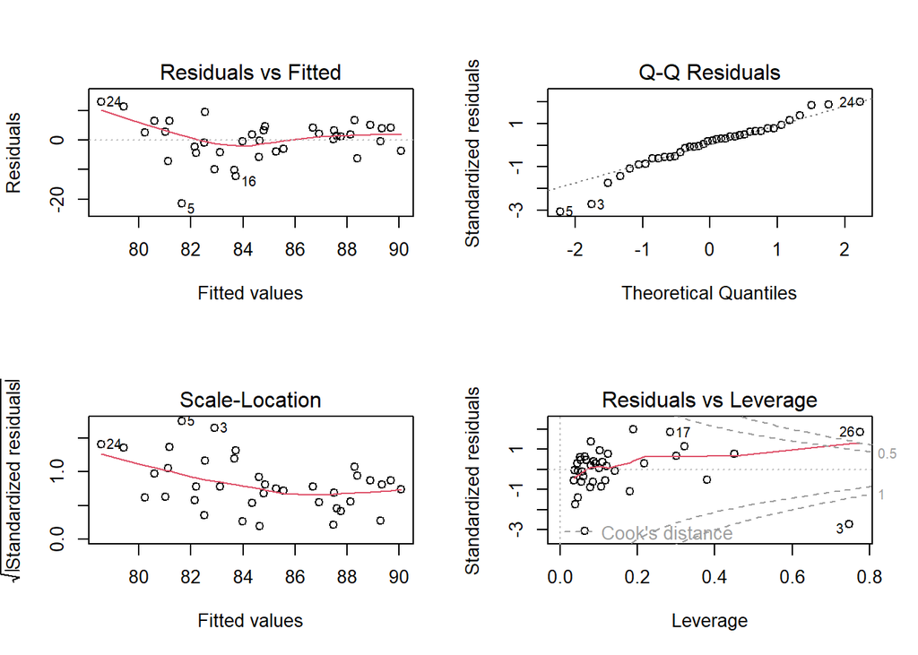

```r
par(mfrow = c(2, 2)) #représentaiton graphique
plot(reg9)
```

Ces diagnostics vérifient que les conditions de Gauss‑Markov sont raisonnablement respectées.

# Représentation de toutes les régressions multiples

```r
screenreg(list(reg4,reg5,reg6,reg7,reg8,reg9), custom.model.names = c("reg4", "reg5","reg6","reg7", "reg8", "reg9"))
```

```
##
## ================================================================================================
##                                 reg4       reg5       reg6       reg7       reg8       reg9
## ------------------------------------------------------------------------------------------------
## (Intercept)                     82.70 ***  79.82 ***  79.40 ***  81.51 ***  81.25 ***  81.12 ***
##                                 (1.55)     (2.99)     (2.87)     (3.23)     (3.20)     (3.29)
## Fraude                           0.01
##                                 (0.00)
## Blanchiment                     -0.00       0.03
##                                 (0.08)     (0.07)
## Corruption                      -0.02       0.01       0.03
##                                 (0.06)     (0.06)     (0.04)
## log_Fraude                                  0.90       0.97       0.97      -0.11      -0.16
##                                            (0.58)     (0.58)     (0.58)     (1.01)     (1.04)
## log_Blanchiment                                        0.12       0.62       0.34       0.45
##                                                       (0.74)     (0.71)     (0.73)     (0.84)
## log_Corruption                                                   -0.81      -0.78      -0.71
##                                                                  (0.78)     (0.77)     (0.83)
## log_Fraude_squared                                                           0.21       0.22
##                                                                             (0.16)     (0.17)
## log_Corruption:log_Blanchiment                                                         -0.07
##                                                                                        (0.28)
## ------------------------------------------------------------------------------------------------
## R^2                              0.16       0.14       0.13       0.14       0.18       0.18
## Adj. R^2                         0.09       0.06       0.05       0.06       0.08       0.06
## Num. obs.                       38         38         38         38         38         38
## ================================================================================================
## *** p < 0.001; ** p < 0.01; * p < 0.05
```

Les variables de criminalité financière (fraude, blanchiment, corruption), qu’elles soient brutes ou transformées, n’ont pas d’effet significatif et stable sur la satisfaction dans ces modèles. Le pouvoir explicatif reste faible (R² ajusté < 10 %), ce qui suggère que des facteurs clés sont absents et que ces indicateurs seuls ne permettent pas de comprendre les variations de satisfaction globale.

En revanche, les VIF sont tous inférieurs à 5, les variables explicatives ne semblent pas être fortement corrélées entre elles. Il n’y a pas de multicolinéarité sévère, mais la corrélation modérée entre certaines variables transformées, notamment log_Fraude et sa version quadratique, peut expliquer la perte de significativité dans le modèle complet.

# ACP : Analyse en Composantes Principales

```r
library(FactoMineR)
library(factoextra)
```

# Sélection des variables pour l’ACP

```r
library(dplyr)
acp_data <- happiness %>%
select(Fraude, Blanchiment, Corruption, Satisfaction)
```

# Vérification des NA

```r
sum(is.na(acp_data))
```

```
## [1] 0
```

On a bien vérifié qu’il n’y a aucune valeur manquante dans notre jeu de données.

# Standaradisation et réalisation de l’ACP

```r
res_acp <- PCA(acp_data, scale.unit = TRUE, graph = FALSE)
```

# Résultats de l’ACP

```r
res_acp
```

```
## **Results for the Principal Component Analysis (PCA)**
## The analysis was performed on 38 individuals, described by 4 variables
## *The results are available in the following objects:
##
##    name               description
## 1  "$eig"             "eigenvalues"
## 2  "$var"             "results for the variables"
## 3  "$var$coord"       "coord. for the variables"
## 4  "$var$cor"         "correlations variables - dimensions"
## 5  "$var$cos2"        "cos2 for the variables"
## 6  "$var$contrib"     "contributions of the variables"
## 7  "$ind"             "results for the individuals"
## 8  "$ind$coord"       "coord. for the individuals"
## 9  "$ind$cos2"        "cos2 for the individuals"
## 10 "$ind$contrib"     "contributions of the individuals"
## 11 "$call"            "summary statistics"
## 12 "$call$centre"     "mean of the variables"
## 13 "$call$ecart.type" "standard error of the variables"
## 14 "$call$row.w"      "weights for the individuals"
## 15 "$call$col.w"      "weights for the variables"
```

# Variance expliquée par les composantes

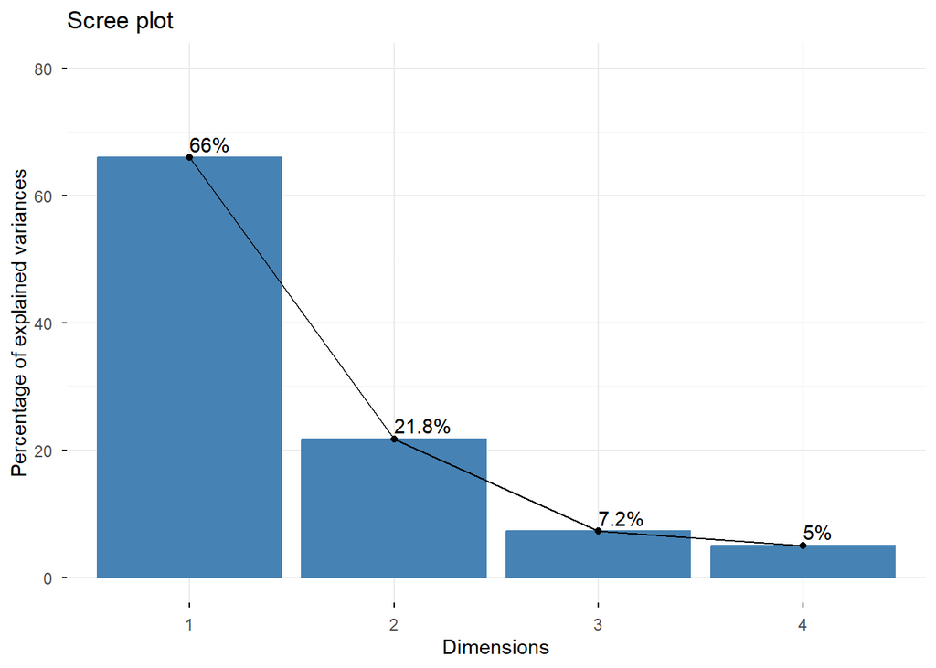

```r
fviz_eig(res_acp, addlabels = TRUE, ylim = c(0, 80))
```

Le Scree Plot montre que les deux premiers axes expliquent 87,8 % de la variance totale, dont 66 % pour le premier axe à lui seul.

Cela montre que l’essentiel de l’information contenue dans les variables Fraude, Corruption, Blanchiment et Satisfaction peut être représenté en deux dimensions.

L’axe 1 résume la quasi-totalité de la variation liée aux crimes économiques, tandis que l’axe 2 apporte des nuances supplémentaires entre les pays. Les axes 3 et 4 n’apportent quasiment pas d’information utile.

# Cercle des corrélations

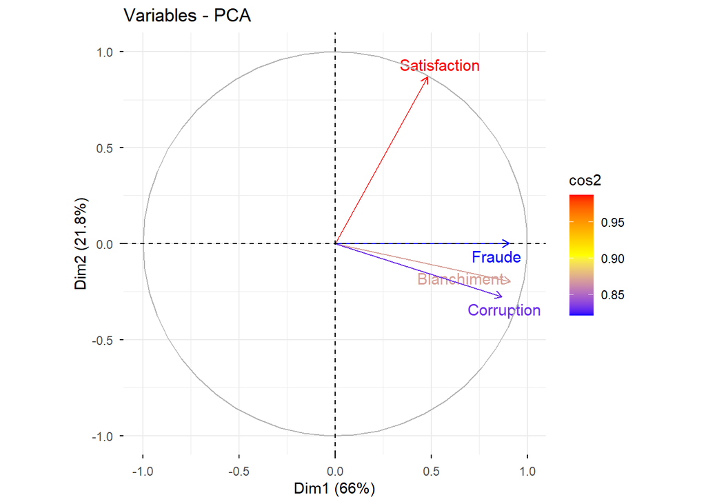

```r
fviz_pca_var(res_acp,
col.var = "cos2",
gradient.cols = c("blue", "yellow", "red"),
repel = TRUE)
```

# Contribution des variables à l’axe 1 et 2

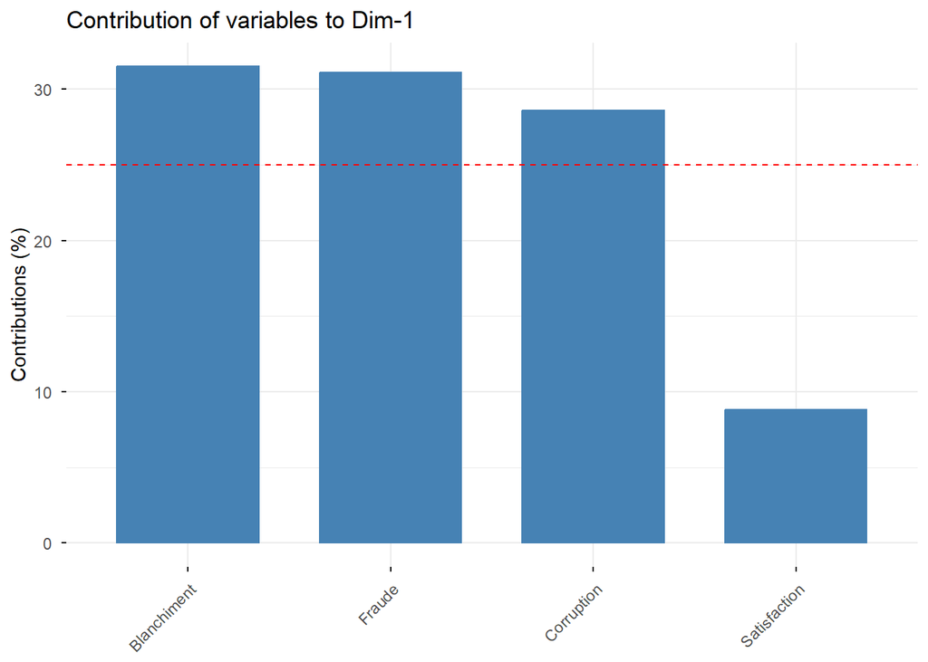

```r
fviz_contrib(res_acp, choice = "var", axes = 1, top = 10)
```

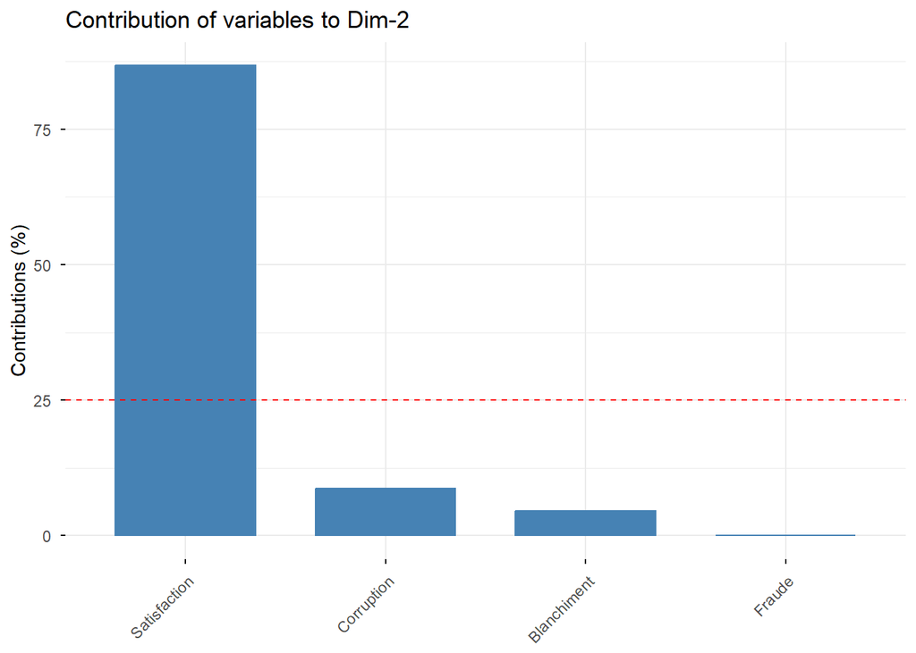

```r
fviz_contrib(res_acp, choice = "var", axes = 2, top = 10)
```

La variable Satisfaction domine très largement l’axe 2, avec une contribution supérieure à 75 %, tandis que Fraude, Blanchiment et Corruption y contribuent très peu. Cela confirme que l’axe 2 reflète une dimension propre à la satisfaction, indépendante des crimes économiques.

# Graphique des individus

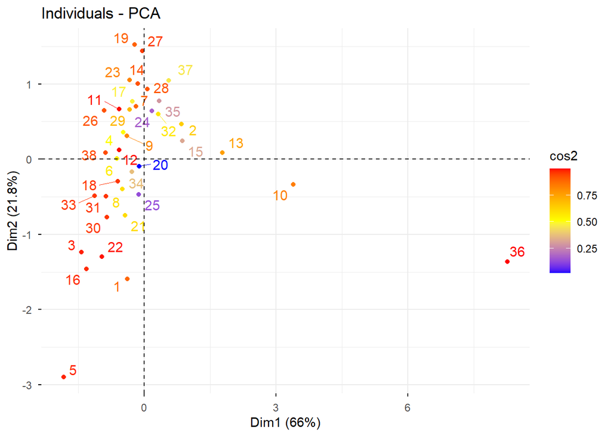

```r
fviz_pca_ind(res_acp,
col.ind = "cos2",
gradient.cols = c("blue", "yellow", "red"),
repel = TRUE)
```

# Clustering sur les axes de l’ACP (CAH ou K-means)

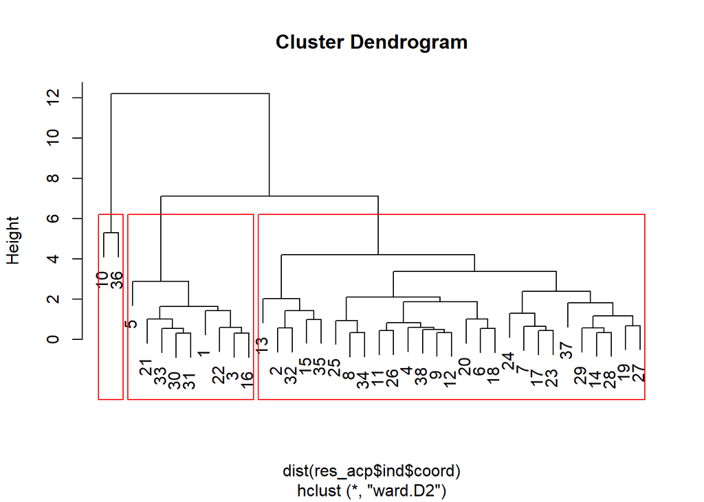

```r
hc <- hclust(dist(res_acp$ind$coord), method = "ward.D2")
plot(hc)
rect.hclust(hc, k = 3, border = "red")
```

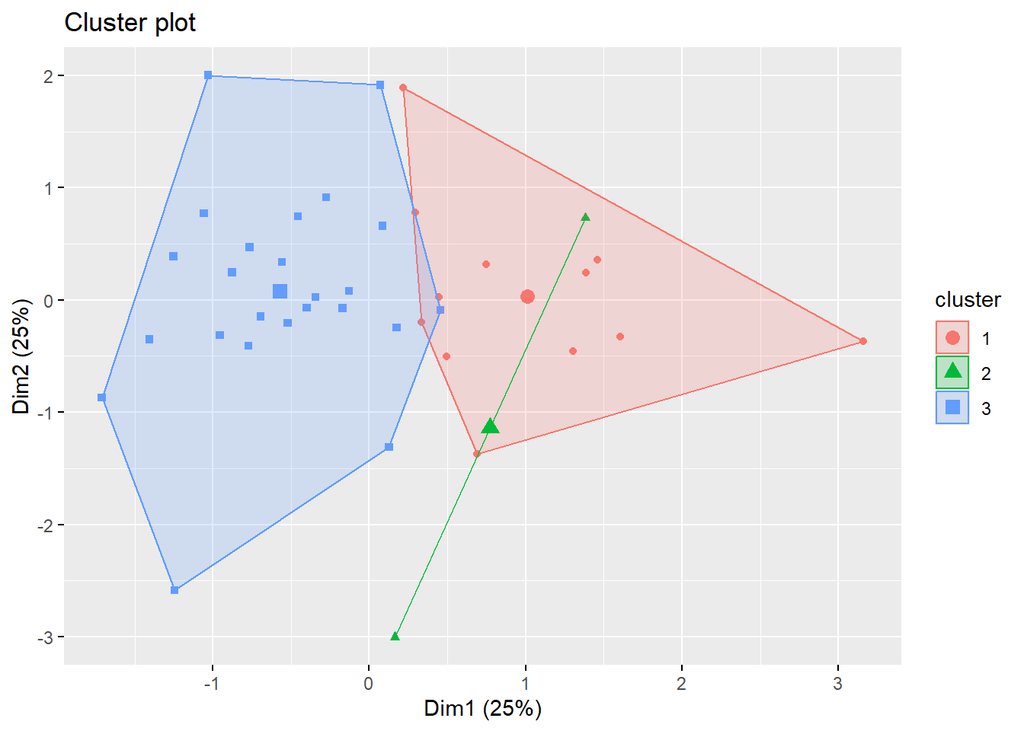

```r
set.seed(123)
km <- kmeans(res_acp$ind$coord, centers = 3)

fviz_cluster(km, data = res_acp$ind$coord,
             geom = "point",
             ellipse.type = "convex")
```

On va alors chercher à identifier trois profils distincts (forte criminalité, forte satisfaction, intermédiaire) et extraire des pays représentatifs pour chaque groupe.

#On identifie trois profils distincts

```r
set.seed(123)
coords <- as.matrix(res_acp$ind$coord)   # vérifier que c'est numérique et sans NA
km <- kmeans(coords, centers = 3)
happiness$cluster <- factor(km$cluster)
```

```r
split(happiness$Country, happiness$cluster)
```

```
## $`1`
##  [1] "Albania"                          "Bolivia (Plurinational State of)"
##  [3] "Bulgaria"                         "Croatia"
##  [5] "Greece"                           "Hungary"
##  [7] "Latvia"                           "Lithuania"
##  [9] "Morocco"                          "Romania"
## [11] "Serbia"                           "Slovakia"
##
## $`2`
## [1] "Denmark" "Sweden"
##
## $`3`
##  [1] "Austria"                "Bosnia and Herzegovina" "Chile"
##  [4] "Colombia"               "Czechia"                "Ecuador"
##  [7] "Estonia"                "Finland"                "France"
## [10] "Germany"                "Guatemala"              "Ireland"
## [13] "Italy"                  "Mexico"                 "Montenegro"
## [16] "Myanmar"                "Norway"                 "Poland"
## [19] "Portugal"               "Singapore"              "Slovenia"
## [22] "Spain"                  "Switzerland"            "Thailand"
```

```r
library(dplyr)
happiness %>%
  group_by(cluster) %>%
  summarise(
    n = n(),
    mean_Fraude = mean(Fraude, na.rm = TRUE),
    mean_Blanchiment = mean(Blanchiment, na.rm = TRUE),
    mean_Corruption = mean(Corruption, na.rm = TRUE),
    mean_Satisfaction = mean(Satisfaction, na.rm = TRUE)
  )
```

```
## # A tibble: 3 × 6
##   cluster     n mean_Fraude mean_Blanchiment mean_Corruption mean_Satisfaction
##   <fct>   <int>       <dbl>            <dbl>           <dbl>             <dbl>
## 1 1          12        76.4             5.10            18.6              76.1
## 2 2           2      1670.            121.             122.               91.9
## 3 3          24       355.              5.90            15.5              88.5
```

```r
coords_df <- as.data.frame(res_acp$ind$coord)
coords_df$Country <- happiness$Country
coords_df$cluster <- km$cluster
centers <- km$centers

# distance euclidienne au centre du cluster
coords_df$dist <- apply(coords_df[,1:2], 1, function(r) {
  cl <- coords_df$cluster[which(coords_df$Country == coords_df$Country[which(coords_df$Country == coords_df$Country)])][1]
  sqrt(sum((r - centers[cl, ])^2))
})

# plus simples : trier par cluster et prendre les 3 plus proches
library(dplyr)
coords_df %>% group_by(cluster) %>% arrange(dist) %>% slice_head(n = 3) %>% select(cluster, Country)
```

```
## # A tibble: 8 × 2
## # Groups:   cluster [3]
##   cluster Country
##     <int> <chr>
## 1       1 Croatia
## 2       1 Morocco
## 3       1 Latvia
## 4       2 Denmark
## 5       2 Sweden
## 6       3 Slovenia
## 7       3 Italy
## 8       3 Chile
```

Conclusion : Pour conclure, on pense souvent que plus un pays est victime de crimes économiques et financiers, et plus cela va affecter négativement le bien-être de la population. Cependant, notre étude nous montre qu’il n’existe pas de lien direct entre les crimes économiques et financiers d’un pays et le bien-être de ses citoyens. Mais nous devons rester prudents concernant nos conclusions puisque notre échantillon n’a pas assez d’observations (nous avons gardé les pays du monde pour lesquels les données étaient disponibles pour l’année 2022) et qu’il se concentre sur une seule année (l’année 2022, la plus récente pour laquelle nous avons des observations).

Pour aller plus loin, nous pourrions étendre nos observations à plusieurs années pour ces mêmes pays et donc agrandir notre échantillon pour travailler avec des données de panel.